# Phosphorus Treatment Effects (Chokwe)

- Show All Code
- Hide All Code
- View Source

Analysis 2 of the PUE hybrid series — the paired optimal-vs-stress phosphorus contrast at Chokwe, across the 11 phenotypes

Author

Fausto Rodriguez Zapata

Published

July 6, 2026

**Paper series — notebook 2.** Shared data preparation: `R/prep_traits.R`.

# 1 Methods (for the paper)

The phosphorus treatment is estimable **only at Chokwe**, the one site grown at both **optimal** (50 kg P ha⁻¹) and **stress** (10 kg P ha⁻¹) levels with the *same* 49 line × tester hybrids (the other four environments each received a single P level, so there the P effect is confounded with site). We therefore restrict this analysis to the Chokwe paired trial: 2 treatments × 3 replications × 49 hybrids = 294 plots.

For each of the 11 phenotypes we fit the mixed model

$$y = \mu + \tau_{\text{treatment}} + r_{(\text{treatment})} + g_{\text{genotype}} + (\tau g)_{\text{genotype}\times\text{treatment}} + \varepsilon,$$

with **treatment fixed** and replication (within treatment), genotype, and genotype × treatment random. The treatment effect is tested with a Kenward–Roger F-test (`lmerTest`); estimated marginal means (optimal, stress) and their difference come from `emmeans`. The genotype × treatment term (whether hybrids *respond differently* to P) is tested by a likelihood-ratio test (`ranova`).

**PUE caveat.** PUE = grain yield / applied P, and applied P is 10 vs 50 kg ha⁻¹ by design, so the optimal-vs-stress difference in PUE is **mechanical (the denominator)**, not a biological response. Read the PUE row as a definitional consequence; the biological P response is in GY and the physiological traits.

```r
library(tidyverse)
library(lme4)
library(lmerTest)     # Kenward-Roger F-tests + ranova
library(emmeans)
library(ggbeeswarm)
library(knitr)
library(kableExtra)

source("R/prep_traits.R")

chokwe <- hybrids %>%
  filter(loc == "CHOKWE") %>%
  mutate(treatment = droplevels(treatment), gen = droplevels(gen))

emm_opts <- emmeans::emm_options(lmerTest.limit = 400, pbkrtest.limit = 400)
ctrl <- lmerControl(check.conv.singular = "ignore", optimizer = "bobyqa",
                    optCtrl = list(maxfun = 2e5))
```

# 2 The phosphorus contrast, trait by trait

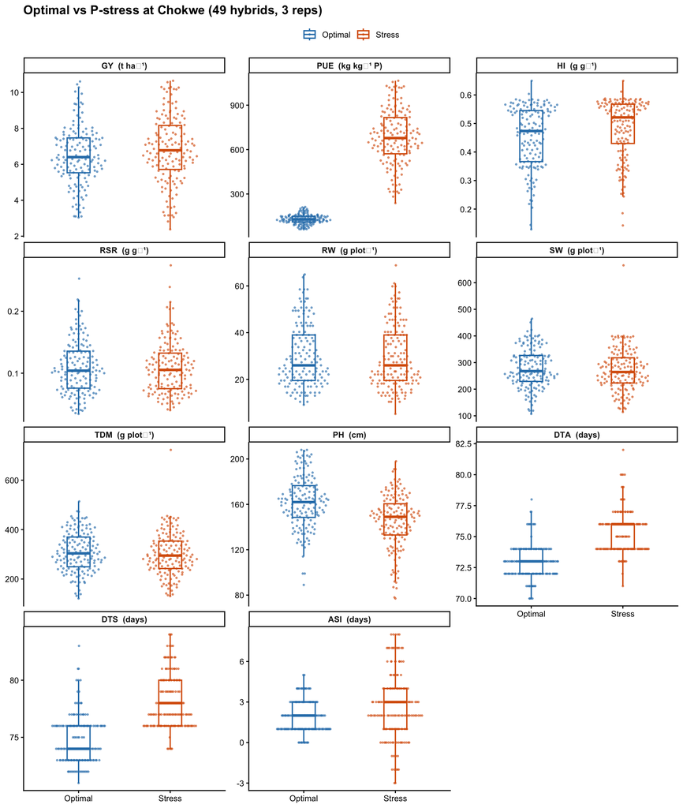

```r
ck_long <- chokwe %>%
  select(treatment, rep, gen, all_of(analysis_traits)) %>%
  pivot_longer(all_of(analysis_traits), names_to = "trait", values_to = "value") %>%
  left_join(trait_meta, by = "trait") %>%
  mutate(panel = factor(paste0(trait, "  (", unit, ")"),
                        levels = paste0(trait_meta$trait, "  (", trait_meta$unit, ")")))

trt_pal <- c("Optimal" = "#2c7fb8", "Stress" = "#d95f0e")

ggplot(ck_long, aes(x = treatment, y = value, color = treatment)) +
  geom_quasirandom(size = 0.6, alpha = 0.55, width = 0.3) +
  geom_boxplot(width = 0.25, linewidth = 0.7, alpha = 0, outlier.shape = NA) +
  facet_wrap(~ panel, scales = "free_y", ncol = 3) +
  scale_color_manual(values = trt_pal, name = NULL) +
  labs(x = NULL, y = NULL,
       title = "Optimal vs P-stress at Chokwe (49 hybrids, 3 reps)") +
  theme_classic(base_size = 12) +
  theme(plot.title = element_text(face = "bold"),
        strip.text = element_text(face = "bold"),
        legend.position = "top")
```

# 3 Treatment effect estimates

```r
fit_trt <- function(tn, d) {
  d <- d %>% mutate(y = .data[[tn]]) %>% filter(!is.na(y))
  m <- suppressMessages(suppressWarnings(
    lmer(y ~ treatment + (1 | treatment:rep) + (1 | gen) + (1 | treatment:gen),
         data = d, control = ctrl)))
  em  <- as.data.frame(emmeans(m, ~ treatment))
  opt <- em$emmean[em$treatment == "Optimal"]
  sts <- em$emmean[em$treatment == "Stress"]
  p_trt <- tryCatch(anova(m)[["Pr(>F)"]][1], error = function(e) NA_real_)
  rv    <- suppressMessages(suppressWarnings(ranova(m)))
  p_gxt <- rv[grepl("treatment:gen", rownames(rv)), "Pr(>Chisq)"]
  tibble(trait = tn, Optimal = opt, Stress = sts,
         diff = opt - sts, pct = 100 * (opt - sts) / sts,
         p_treatment = p_trt, p_GxT = ifelse(length(p_gxt), p_gxt, NA_real_))
}

trt_res <- map_dfr(analysis_traits, fit_trt, d = chokwe) %>%
  left_join(trait_meta, by = "trait") %>%
  arrange(trait)

trt_res %>%
  transmute(
    Group = group, Trait = trait, Unit = unit,
    Optimal = round(Optimal, 3), Stress = round(Stress, 3),
    `Δ (Opt−Str)` = round(diff, 3), `% change` = round(pct, 1),
    `p (treatment)` = signif(p_treatment, 3),
    `p (G×T)` = signif(p_GxT, 3),
    Effect = case_when(is.na(p_treatment) ~ "—",
                       p_treatment < 0.05 & diff > 0 ~ "↓ under stress",
                       p_treatment < 0.05 & diff < 0 ~ "↑ under stress",
                       TRUE ~ "n.s.")
  ) %>%
  kable(caption = "Chokwe optimal-vs-stress phosphorus effect per trait. Δ and % change are optimal − stress (marginal means); p(treatment) = Kenward–Roger F-test; p(G×T) = LRT for genotype × treatment. PUE is denominator-driven (see caveat).") %>%
  kable_styling(bootstrap_options = c("striped", "hover", "condensed"), full_width = FALSE) %>%
  collapse_rows(columns = 1, valign = "top")
```

Chokwe optimal-vs-stress phosphorus effect per trait. Δ and % change are optimal − stress (marginal means); p(treatment) = Kenward–Roger F-test; p(G×T) = LRT for genotype × treatment. PUE is denominator-driven (see caveat).

| Group | Trait | Unit | Optimal | Stress | Δ (Opt−Str) | % change | p (treatment) | p (G×T) | Effect |
| --- | --- | --- | --- | --- | --- | --- | --- | --- | --- |
| C – Auxiliary | ASI | days | 1.905 | 2.735 | -0.830 | -30.3 | 2.63e-02 | 0.97000 | ↑ under stress |
|  | DTA | days | 72.959 | 75.401 | -2.442 | -3.2 | 9.70e-06 | 0.01240 | ↑ under stress |
|  | DTS | days | 74.864 | 78.136 | -3.272 | -4.2 | 6.59e-04 | 0.05800 | ↑ under stress |
| A – Selection | GY | t ha⁻¹ | 6.494 | 6.835 | -0.340 | -5.0 | 4.63e-01 | 1.00000 | n.s. |
| B – Physiological | HI | g g⁻¹ | 0.454 | 0.485 | -0.032 | -6.5 | 2.34e-01 | 1.00000 | n.s. |
| C – Auxiliary | PH | cm | 162.041 | 144.939 | 17.102 | 11.8 | 3.70e-06 | 0.00808 | ↓ under stress |
| A – Selection | PUE | kg kg⁻¹ P | 129.884 | 683.456 | -553.571 | -81.0 | 1.04e-04 | 0.88600 | ↑ under stress |
| B – Physiological | RSR | g g⁻¹ | 0.110 | 0.109 | 0.001 | 0.6 | 9.61e-01 | 1.00000 | n.s. |
|  | RW | g plot⁻¹ | 30.094 | 29.493 | 0.601 | 2.0 | 9.04e-01 | 1.00000 | n.s. |
|  | SW | g plot⁻¹ | 279.295 | 271.186 | 8.110 | 3.0 | 6.52e-01 | 1.00000 | n.s. |
|  | TDM | g plot⁻¹ | 309.389 | 300.678 | 8.711 | 2.9 | 6.97e-01 | 1.00000 | n.s. |

# 4 Summary

- **Which traits respond to P at Chokwe** are the rows with a significant `p (treatment)` — the biological phosphorus response (read GY and the Group-B physiological traits; PUE is mechanical).
- **Genotype × treatment** (`p (G×T)`) flags traits where hybrids *differ in their P response* — the traits where a stress-specific ranking of hybrids exists, relevant to selecting for the low-P target environment.
- This paired contrast is the clean estimate of the P effect; the multi-environment G×E (across all five environments) is handled in the combining-ability notebooks (3–4).